# Facial Recognition

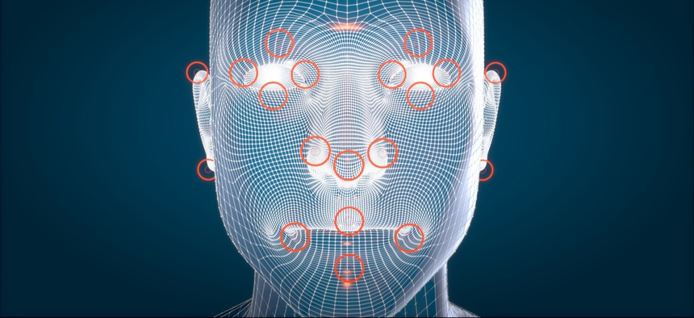

# Introduction

### Class: W207

### Team Name: Choo-Choo-Train

### Team Members:

1. Jordan Meyer
2. Amit Thiruvengadam
3. Sweeta Bee
4. Leon Gutierrez

# Instruction to run code

## Preparation

- In the data folder unzip “facial-keypoints-detection.zip”
- This will create a folder called “facial-keypoints-detection”. Move the contents of this folder, namely, IdlookupTable.csv, SampleSubmission.csv, train.csv, test.csv into the “data”" folder
- Next unzip training.zip and test.zip and move training.csv and test.csv into the data folder
- Your folder structure should now look like this:

```
Choo-Choo-Train
      |_data
           |_IdLookupTable.csv
           |_SampleSubmission.csv
           |_training.csv
           |_test.csv
           |_models (empty folder)
           |_analysis (folder with some content)
           |_augment (empty folder)
      |_notebooks
           |_ main.ipynb
           |_ image_analysis.ipynb
      |_README.md (this file)
      |___init__.py
```

## Note: Please rename the main folder to cct. It should now look like this

```
cct
  |_data
       |_IdLookupTable.csv
       |_SampleSubmission.csv
       |_training.csv
       |_test.csv
       |_models (empty folder)
       |_analysis (folder with some content)
       |_augment (empty folder)
  |_notebooks
       |_ main.ipynb
       |_ image_analysis.ipynb
  |_README.md (this file)
  |___init__.py
```

## Creating models

- Models take ~15hrs to generate on a GPU and must be run on a High RAM machine
- Move the entire folder structure to Google Drive and place it in your Colab Notebook folder. It should now look like this:

```
|_drive
      |_MyDrive
            |_Colab Notebooks
                          |_cct
```

- open main.ipynb from the notebooks folder and follow instruction on first cell
- It creates a file called CNNMySubmission.csv that can be submitted for the Kaggle competition

```
cct
  |_data
       |_CNNMySubmission.csv
```

## Analysis

- open image_analysis.ipynb from the notebooks folder and run all cells